# Bibliographic Studies

Country Based Comparison

Serdar Balcı, MD, Pathologist

2018-06-27

# 1 Analysis

## 1.1 PubMed Indexed Peer Reviewed Articles in Pathology Journals: A country based comparison

**Aim:**

Here, we are going to compare 3 countries (German, Japan and Turkey), in terms of number of articles in pathology journals during the last decade.

**Methods:**

If you want to see the code used in the analysis please click the code button on the right upper corner or throughout the page.

```r
# load required packages
library(tidyverse)
library(RISmed)
```

Pathology Journal ISSN List was retrieved from [In Cites Clarivate](https://jcr.incites.thomsonreuters.com/), and Journal Data Filtered as follows: `JCR Year: 2016 Selected Editions: SCIE,SSCI Selected Categories: 'PATHOLOGY' Selected Category Scheme: WoS`

```r
# Get ISSN List from data downloaded from WoS
ISSNList <- JournalHomeGrid <- read_csv("data/JournalHomeGrid.csv",
                                        skip = 1) %>%
    select(ISSN) %>%
    filter(!is.na(ISSN)) %>%
    t() %>%
    paste("OR ", collapse = "") # add OR between ISSN List
ISSNList <- gsub(" OR $","" ,ISSNList) # to remove last OR
```

Data is retrieved from PubMed via RISmed package. PubMed collection from National Library of Medicine (https://www.ncbi.nlm.nih.gov/pubmed/), has the most comprehensive information about peer reviewed articles in medicine. The API (https://dataguide.nlm.nih.gov/), and R packages are available for getting and fetching data from the server.

The search formula for PubMed is generated as “ISSN List AND Country[Affiliation]” like done in [advanced search of PubMed](https://www.ncbi.nlm.nih.gov/pubmed/advanced).

```r
# Generate Search Formula For Pathology Journals AND Countries
searchformulaTR <- paste("'",ISSNList,"'", " AND ", "Turkey[Affiliation]")
searchformulaDE <- paste("'",ISSNList,"'", " AND ", "Germany[Affiliation]")
searchformulaJP <- paste("'",ISSNList,"'", " AND ", "Japan[Affiliation]")
```

```r
# Search PubMed, Get and Fetch
TurkeyArticles <- EUtilsSummary(searchformulaTR, type = 'esearch', db = 'pubmed', mindate = 2007, maxdate = 2017, retmax = 10000)
fetchTurkey <- EUtilsGet(TurkeyArticles)

GermanyArticles <- EUtilsSummary(searchformulaDE, type = 'esearch', db = 'pubmed', mindate = 2007, maxdate = 2017, retmax = 10000)
fetchGermany <- EUtilsGet(GermanyArticles)

JapanArticles <- EUtilsSummary(searchformulaJP, type = 'esearch', db = 'pubmed', mindate = 2007, maxdate = 2017, retmax = 10000)
fetchJapan <- EUtilsGet(JapanArticles)
```

From the fetched data the year of articles are grouped and counted by country.

```r
# Articles per countries per year
tableTR <- table(YearPubmed(fetchTurkey)) %>%
    as_tibble() %>%
    rename(Turkey = n, Year = Var1)
tableDE <- table(YearPubmed(fetchGermany)) %>%
    as_tibble() %>%
    rename(Germany = n, Year = Var1)
tableJP <- table(YearPubmed(fetchJapan)) %>%
    as_tibble() %>%
    rename(Japan = n, Year = Var1)
# Join Tables
articles_per_year_table <- list(
    tableTR,
    tableDE,
    tableJP
    ) %>%
    reduce(left_join, by = "Year", .id = "id")
```

```r
# Prepare table for output
articles_per_year <- articles_per_year_table %>%
    gather(Country, n, 2:4)
articles_per_year$Country <- factor(articles_per_year$Country,
                                       levels =c("Japan", "Germany", "Turkey"))
```

**Result:**

In the below table we see the number of articles per country in the last decade.

| Year | Turkey | Germany | Japan |
| --- | --- | --- | --- |
| 2007 | 75 | 398 | 693 |
| 2008 | 89 | 314 | 620 |
| 2009 | 89 | 364 | 636 |
| 2010 | 100 | 347 | 661 |
| 2011 | 108 | 386 | 731 |
| 2012 | 79 | 389 | 666 |
| 2013 | 79 | 415 | 758 |
| 2014 | 93 | 465 | 733 |
| 2015 | 140 | 466 | 753 |
| 2016 | 140 | 419 | 683 |
| 2017 | 106 | 421 | 660 |

And the figure below shows this data in a line graph.

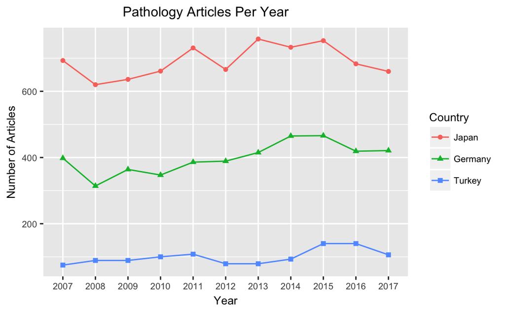

**Comment:**

We see that Japan has much more articles than German and Turkey. Turkey has a small increase in number of articles.

**Future Work:**

- Indentify why Japan has too much articles.
- Compare Japan with other countries.
- Compare Turkey with neighbours, EU, OECD & Middle East countries.
- Analyse multinational studies.
- Analyse adding journal impact as a factor.

# 2 Feedback

[Serdar Balcı, MD, Pathologist](https://github.com/sbalci) would like to hear your feedback: https://goo.gl/forms/YjGZ5DHgtPlR1RnB3

This document will be continiously updated and the last update was on 2018-06-27.

# 3 Back to Main Menu

[Main Page for Bibliographic Analysis](https://sbalci.github.io/pubmed/BibliographicStudies.html)